# Credit Risk and Macroeconomic Indicators in Bulgaria

### Gross domestic product at market prices

### Price index (implicit deflator), 2010=100, Euro

### Seasonally and calendar adjusted data

### Quarterly data

### 2000Q1 - 2016Q4

```r
gdp <- get_eurostat(id='namq_10_gdp',time_format = 'date',update_cache=TRUE,
                    filters= list(geo='BG',unit='PD10_EUR',s_adj='SCA',na_item='B1GQ'))

ll <- process(gdp,'q','GDP','Monthly Price index, 2010=100','GDP at market prices - Seasonally and calendar adjusted data')
```

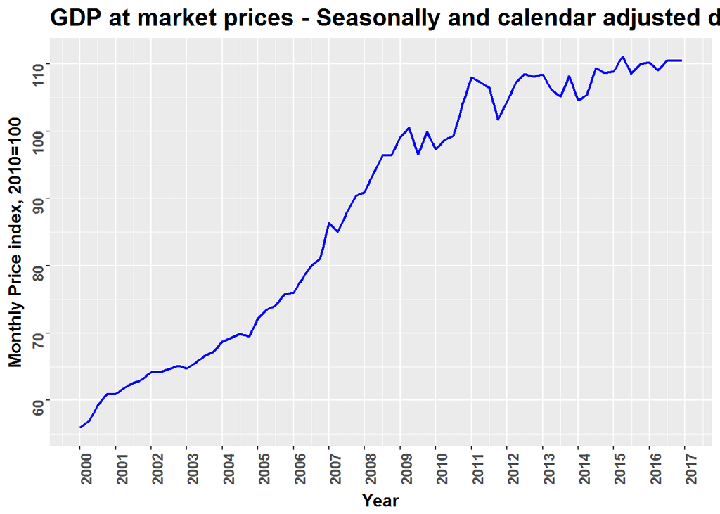

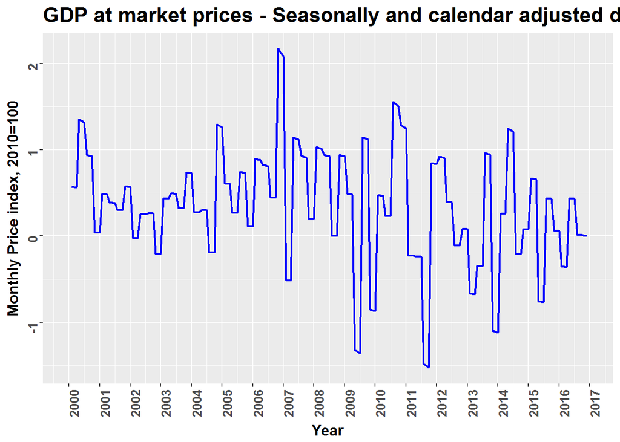

```r
gdp2 <- ll$df2
```

### Nonperforming to total gross loans

### Yearly data

### 2000 - 2015

### World Bank Database

### http://data.worldbank.org/indicator/FB.AST.NPER.ZS?locations=BG

```r
npl <- WDI(country = c('BG'), indicator = "FB.AST.NPER.ZS",
start = 2000, end = 2015, extra = TRUE, cache = NULL)

npl <- npl[,c('year','FB.AST.NPER.ZS')]
names(npl) <- c('time','values')
npl$time <- as.Date(paste(as.character(npl$time),'-01-01',sep=''))

ll <- process(npl,'y','NPL','% of gross loans','Non-performing loans')
```

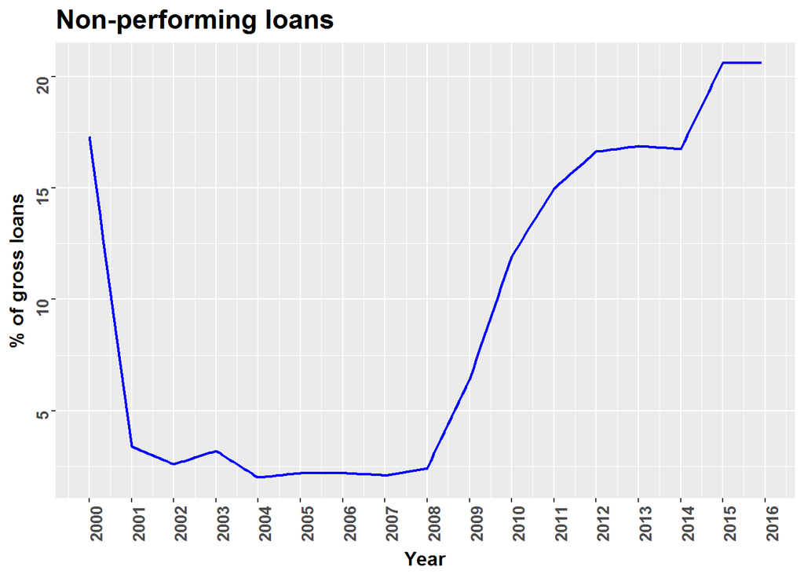

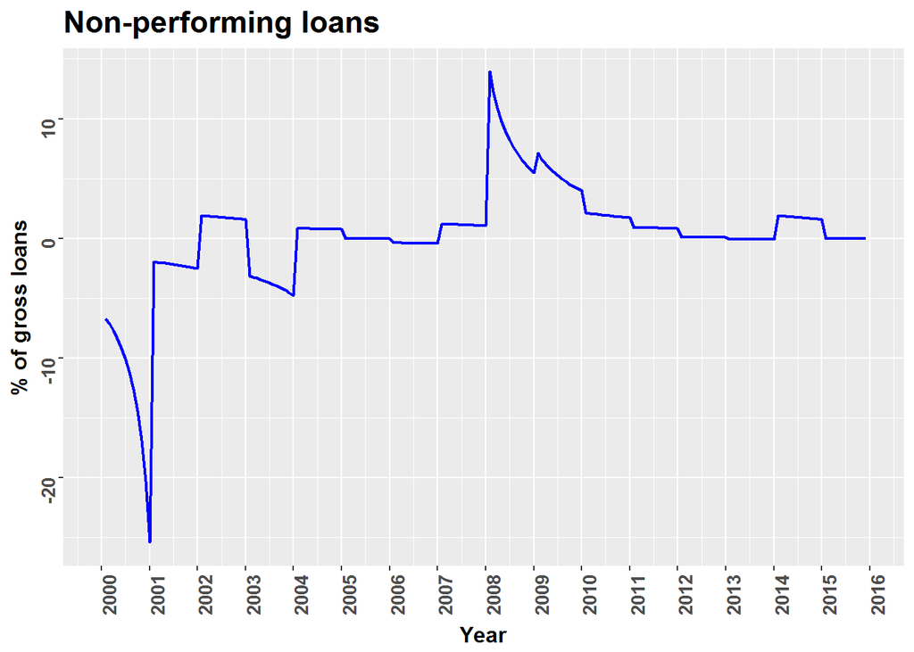

```r
npl2 <- ll$df2


dat <- merge(gdp2,npl2,by=c('time'),all = TRUE)
write.csv(dat,file='data.csv')
```

### Total unemployment rate: % of the active population 15-74

### Quarterly data

### 2000Q1 - 2016Q4

```r
## Total unemployment rate: % of the active population
## LFS adjusted series

unempl <- get_eurostat(id='lfsq_urgan',time_format = 'date',update_cache=TRUE,
                    filters= list(age='Y15-74', citizen='TOTAL',sex='T', geo='BG'))


ll <- process(unempl,'q','Unempl','% of the active population','Total unemployment rate')
```

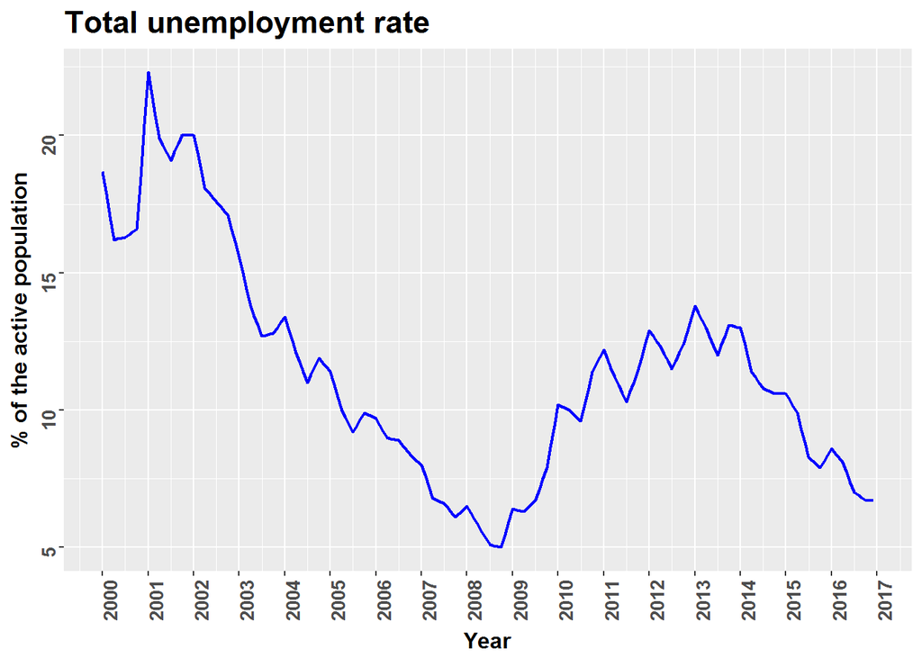

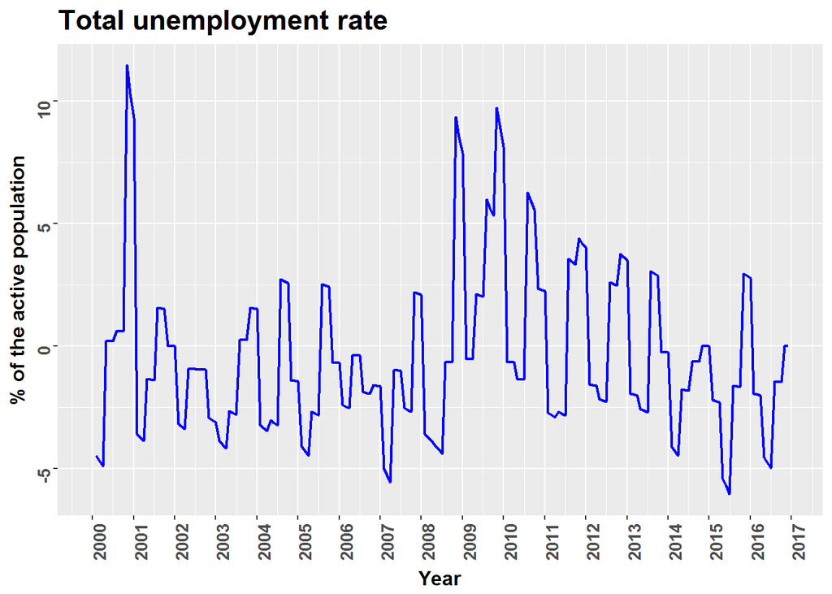

```r
unempl2 <- ll$df2

dat <- merge(dat,unempl2,by=c('time'),all = TRUE)
write.csv(dat,file='data.csv')
```

### House price index (2010 = 100) - quarterly data

### Total purchases

### Quarterly data

### 2005Q1 - 2016Q4

```r
hpi <- get_eurostat(id='prc_hpi_q',time_format = 'date',update_cache=TRUE,
                    filters= list(unit='INX_Q', typpurch='TOTAL',geo='BG'))

ll <- process(hpi,'q','HPI','Index (2010 = 100)','House price index')
```

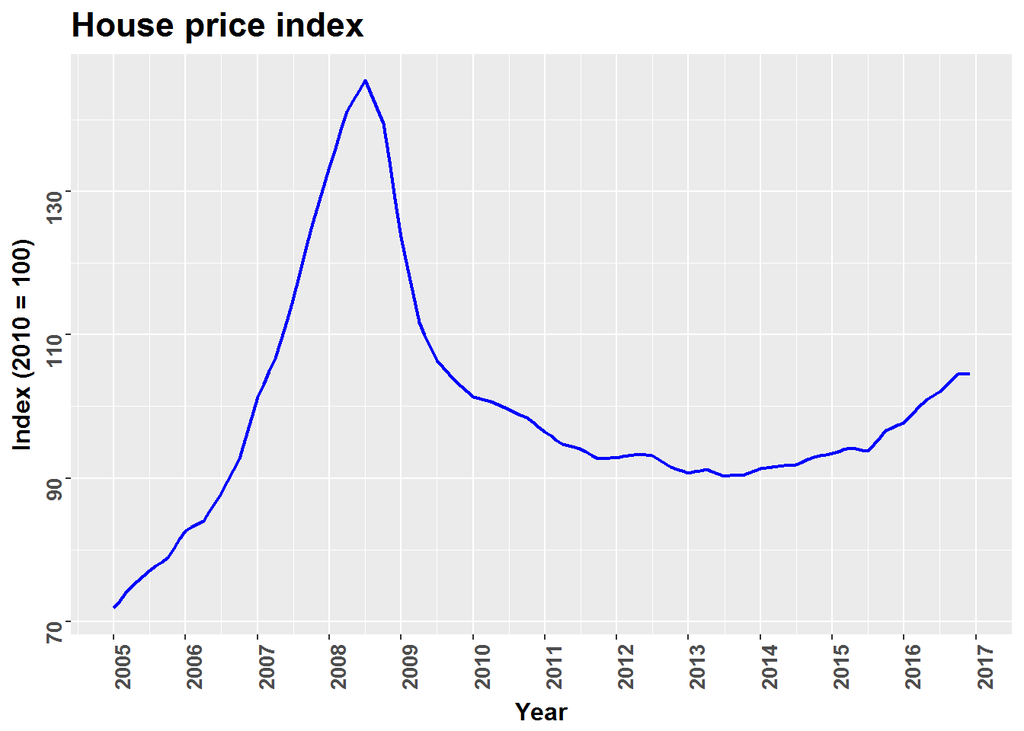

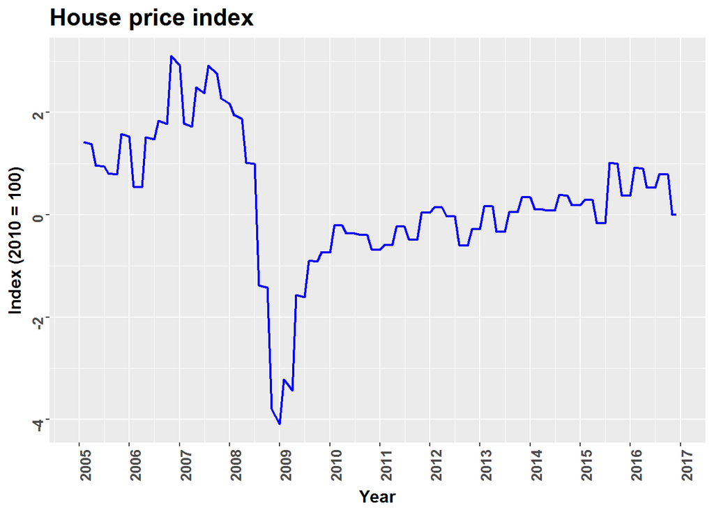

```r
hpi2 <- ll$df2

dat <- merge(dat,hpi2,by=c('time'),all = TRUE)
write.csv(dat,file='data.csv')
```

### From the World Bank Database:

### Inflation, consumer prices (annual %)

### Yearly data

### 2000-2015

### http://data.worldbank.org/indicator/FP.CPI.TOTL.ZG?locations=BG

```r
inflat <- WDI(country = c('BG'), indicator = "FP.CPI.TOTL.ZG",
start = 2000, end = 2015, extra = TRUE, cache = NULL)
inflat <- inflat[,c('year','FP.CPI.TOTL.ZG')] ;
names(inflat) <- c('time','values')

inflat$time <- as.Date(paste(as.character(inflat$time),'-01-01',sep=''))


ll <- process(inflat,'y','Inflation','Inflation','Inflation')
```

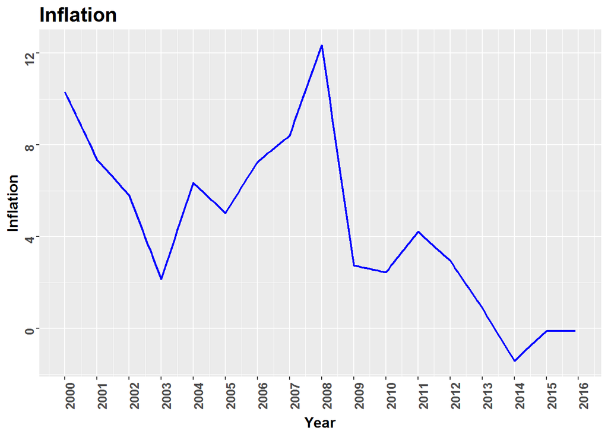

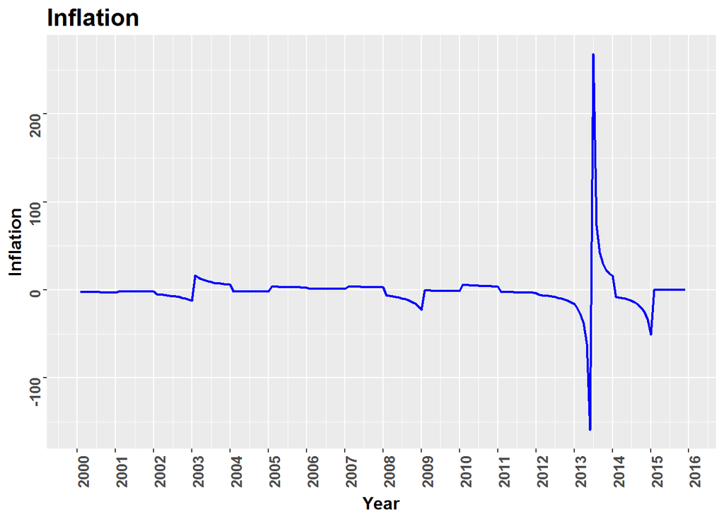

```r
inflat2 <- ll$df2


dat <- merge(dat,inflat2,by=c('time'),all = TRUE)
write.csv(dat,file='data.csv')
```

## EMU convergence criterion bond yields - monthly data

## calculating Greek-German 10-year bond spread

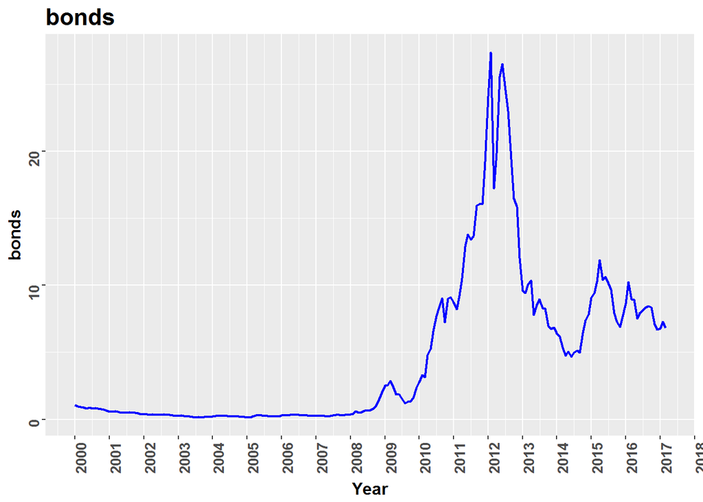

```r
bonds <- get_eurostat(id='irt_lt_mcby_m',time_format = 'date',update_cache=TRUE)
bonds <- bonds[bonds$geo=='EL' | bonds$geo=='DE',]
bonds <- bonds[year(bonds$time) >= 2000,]
bonds <- dcast(bonds, time ~ geo, value.var = 'values')
bonds$values <- bonds$EL-bonds$DE
bonds <- bonds[,c('time','values')]

bonds$values <- ts(bonds$values,start=c(2000,1),end=c(2017,3),
                   frequency=12)

bonds$values <- na.interpolation(bonds$values, option = "linear")

bonds2 <- compute_change(bonds)
bonds2$V3 <- ts(bonds2$V3,start=c(2000,1),end=c(2017,3),frequency=12)

names(bonds2)<-c('time','Bonds','Bonds_change')

plots <- graph (bonds2,'bonds','bonds')
plots$p1
```

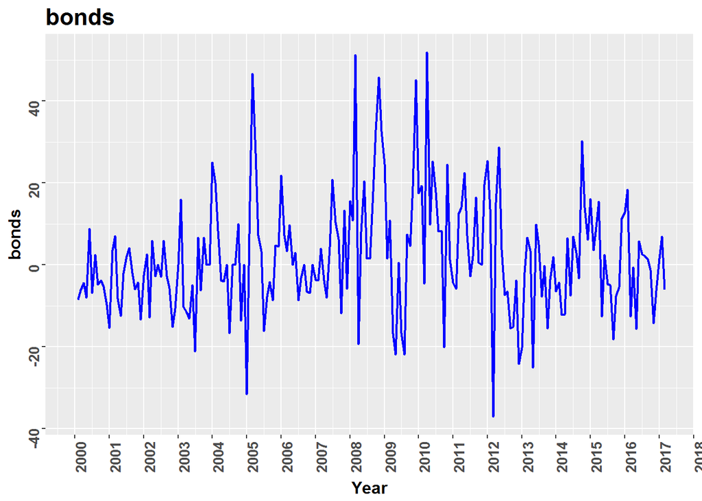

```r
plots$p2
```

```r
rm(bonds)

dat <- merge(dat,bonds2,by=c('time'),all = TRUE)
write.csv(dat,file='data.csv')
```

## average bank interest rates

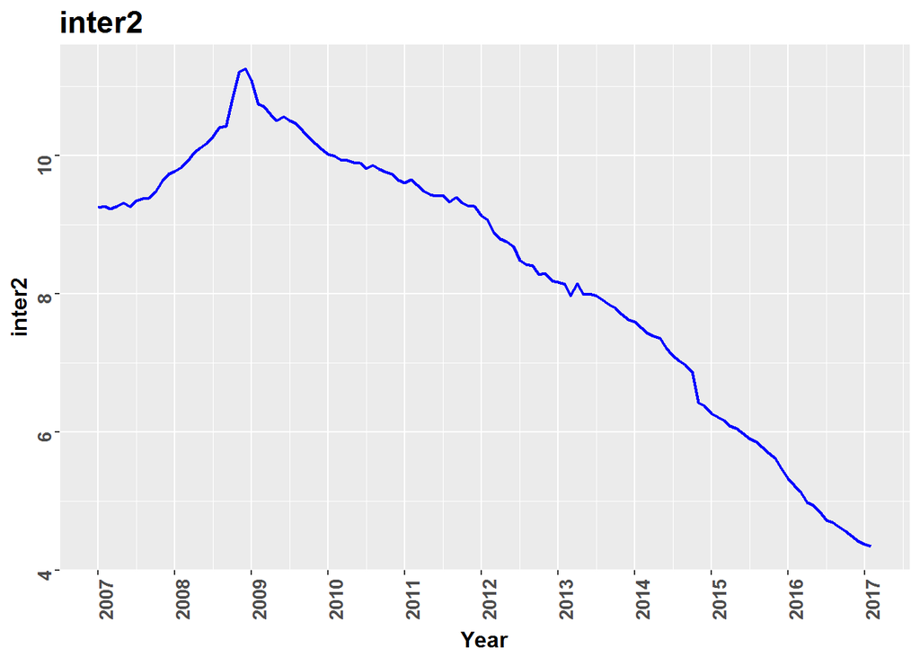

```r
inter <- read.csv(file='interest_rates.csv',skip = 4,header=TRUE,
                  stringsAsFactors = FALSE)
names(inter) <- c('time','rate1','rate2','rate3')

inter$rate <- rowMeans(inter[,2:4])

inter$year <- as.numeric(substr(inter$time,1,4))
inter$month <- substr(inter$time,5,length(inter$time))

inter$time2 <- paste(inter$year,inter$month,'01',sep='-')
inter$time3 <- as.Date(inter$time2,format='%Y-%b-%d')

inter <- inter[, c('time3','rate')]
names(inter) <- c('time','values')

ord <- order(inter$time)
inter <- inter[ord,]

inter$values <- ts(inter$values,start=c(2007,1),end=c(2017,2),
                   frequency=12)

inter2 <- compute_change(inter)
inter2$V3 <- ts(inter2$V3,start=c(2007,1),end=c(2017,2),frequency=12)

names(inter2)<-c('time','Inter','Inter_change')

plots <- graph (inter2,'inter2','inter2')
plots$p1
```

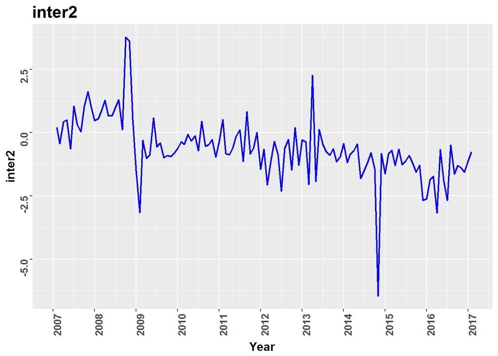

```r
plots$p2
```

```r
rm(inter)

dat <- merge(dat,inter2,by=c('time'),all = TRUE)
write.csv(dat,file='data.csv')
```

```r
for(j in 2:ncol(dat) )
  dat[,j] <- ts(dat[,j], start=c(2000,1), end=c(2017,3), frequency = 12)

model0 <- lm(NPL ~ . -time -NPL_change, data=dat)
summary(model0)
```

```
##
## Call:
## lm(formula = NPL ~ . - time - NPL_change, data = dat)
##
## Residuals:
##      Min       1Q   Median       3Q      Max
## -1.54383 -0.64929 -0.05721  0.62243  2.40993
##
## Coefficients:
##                    Estimate Std. Error t value Pr(>|t|)
## (Intercept)      -23.014585   4.676446  -4.921 3.66e-06 ***
## GDP                0.505617   0.040891  12.365  < 2e-16 ***
## GDP_change        -0.101291   0.128425  -0.789 0.432262
## Unempl            -0.190524   0.093543  -2.037 0.044487 *
## Unempl_change      0.047781   0.030232   1.581 0.117351
## HPI               -0.101711   0.015684  -6.485 4.09e-09 ***
## HPI_change         0.640942   0.186816   3.431 0.000896 ***
## Inflation         -0.426326   0.088473  -4.819 5.53e-06 ***
## Inflation_change  -0.001253   0.002740  -0.457 0.648463
## Bonds              0.059350   0.023529   2.522 0.013337 *
## Bonds_change       0.022325   0.006024   3.706 0.000356 ***
## Inter             -0.274724   0.184348  -1.490 0.139506
## Inter_change       0.058182   0.096395   0.604 0.547579
## ---
## Signif. codes:  0 '***' 0.001 '**' 0.01 '*' 0.05 '.' 0.1 ' ' 1
##
## Residual standard error: 0.942 on 94 degrees of freedom
##   (100 observations deleted due to missingness)
## Multiple R-squared:  0.9789, Adjusted R-squared:  0.9762
## F-statistic: 363.3 on 12 and 94 DF,  p-value: < 2.2e-16
```

[output not shown]